```python
from math import pi
from PIL import Image
from scipy import ndimage
from scipy import signal
from timeit import default_timer as timer
import numpy.fft as fft
import numpy as np
import matplotlib.pyplot as plt
import math as math
import glob
import os
import sys

sys.path.append("../lab1/")  # set the path for visualPercepUtils.py
import visualPercepUtils as vpu

plt.gray()
figure_size = (7, 7)
```

```python
def FT(im):
    # https://numpy.org/doc/stable/reference/generated/numpy.fft.fft2.html
    return fft.fftshift(fft.fft2(im))  # perform also the shift to have lower frequencies at the center


def IFT(ft):
    return fft.ifft2(fft.ifftshift(ft))  # assumes ft is shifted and therefore reverses the shift before IFT
```

# Exercise 1

As you can see I computed the Fourier Transform and ploted the Original image beside the log Magnitude and Phase plots. The minimum and maximum values of the maginitude are also printed.

```
Minimum: 6.177454925709236 Maximum: 8286707.0
3 None None
```

[figure not shown]

```python
file = './imgs-P3/lena255.pgm'
im = np.array(Image.open(file).convert('L'))
im_ft = FT(im)
magnitude = np.absolute(im_ft)
log_magnitude = np.log(np.absolute(im_ft))
phase = np.angle(im_ft)
print('Minimum:', np.min(magnitude),'Maximum:', np.max(magnitude))
vpu.showInGrid([im, log_magnitude, phase], figure_size, subtitles=["Original", "log Magnitude", "Phase"])
```

The results of the minimum and maximum give really strange values, the value of the maximum is really big and can be seen here in the boxplot. Why this value? And only one? Maybe I should research or try to apply some bandpass filter to try to identify what is that frequency. Update: higher frequencies are related to more finer detail and low frequencies to more wide characteristics of the image (I think the word might be coarser). So it might be related to some kind of image color relevance (something like the brightness level).

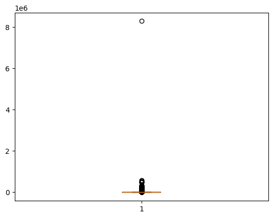

```python
plt.boxplot(magnitude.flatten())
plt.show()
```

The phase seems fine. What makes it symetric? Is it because of some periodic property of the Fourier Transform?

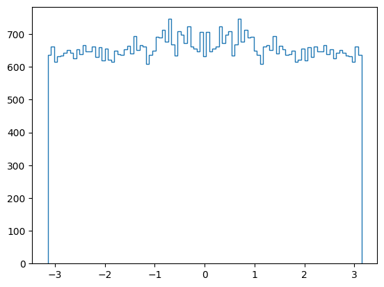

```python
plt.hist(phase.flatten(), bins=np.linspace(-pi, pi, 100), density=False, histtype='step')
plt.show()
```

# Exercise 2

We first define our filters and use filterFrequency method to compute the fourier trnasform and apply the filter. The filterFrequency method is modified to also output the FT of the image.

```python
def avgFilter(filterSize):
    mask = np.ones((filterSize, filterSize))
    return mask/np.sum(mask)

def averageFilterSpace(im, filterSize):
    return ndimage.convolve(im, avgFilter(filterSize))

def gaussianFilter(sigma=5):
    gv1d = signal.windows.gaussian(2 * round(4.0 * sigma) + 1, sigma).reshape(2 * round(4.0 * sigma) + 1, 1)
    gv2d = gv1d * gv1d.T
    return np.divide(gv2d, np.sum(gv2d))

def gaussianFilterSpace(im, sigma=5):
    return ndimage.convolve(im, gaussianFilter(sigma))

def filterFrequency(im, filter, *args):
    filterMask = filter(args[0])  # the usually small mask
    filterBig = np.zeros_like(im, dtype=float)  # as large as the image (dtype is important here!)
    w, h = filterMask.shape     ## First, get sizes
    w2, h2 = w / 2, h / 2  # half width and height of the "small" mask
    W, H = filterBig.shape
    W2, H2 = W / 2, H / 2  # half width and height of the "big" mask
    filterBig[int(W2 - w2):int(W2 + w2), int(H2 - h2):int(H2 + h2)] = filterMask     ## Then, paste the small mask at the center using the sizes computed before as an aid
    filterBig = fft.ifftshift(filterBig)  # FFT of the big filter: shift origin at upper-left corner
    return FT(filterBig), FT(im), np.real(IFT(FT(im) * FT(filterBig)))  # both '*' and multiply() perform elementwise product
```

After applying the gaussian filter you can see there is no difference between the two approaches. Even the RMS is really low. The convolution theorem works!

```
0.004983252341079681
2 None None
```

[figure not shown]

```python
filter_ft, im2_ft, im2 = filterFrequency(im, gaussianFilter, 5)
im2_space = gaussianFilterSpace(im, 5)

margin = 5  # exclude some outer pixels to reduce the influence of border effects
rms = np.linalg.norm(im2_space[margin:-margin, margin:-margin] - im2[margin:-margin, margin:-margin], 2) / np.prod(im.shape)
print(rms)
vpu.showInGrid([im2_space, im2], figure_size, subtitles=["Space filter", "Fourier filter"])
```

Now we want to see the fourier transforms of the image, the filter and the product of the image and filter. First we have to calculate the log magnitude (log to avoid big differences in values as seen in the boxplot of the exercise 1) and the phase of each fourier transform and of the product. As you can see the log magnitude of the product is eassily seen as a sum beacuse of the logarithmic properties.

```
6 3 2
```

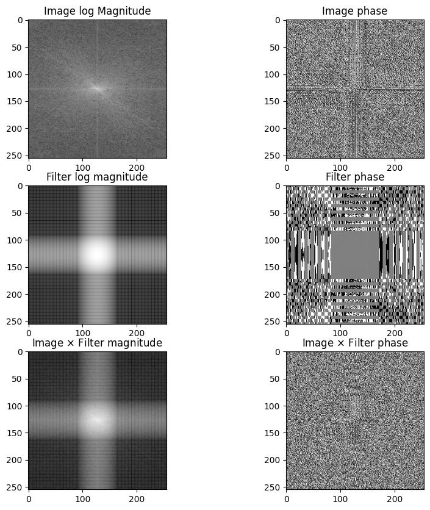

```python
magnitude_or = np.log(np.absolute(im2_ft))
phase_or = np.angle(im2_ft)
magnitude_filter = np.log(np.absolute(filter_ft))
phase_filter = np.angle(filter_ft)
magnitude_prod = np.log(np.absolute(filter_ft*im2_ft))
phase_prod = np.angle(filter_ft*im2_ft)
vpu.showInGrid([magnitude_or, phase_or, magnitude_filter, phase_filter, magnitude_prod, phase_prod], figure_size=(10,10), m=3,n=2, subtitles=["Image log Magnitude", "Image phase", "Filter log magnitude", "Filter phase",
                                                                                                                             "Image $\\times$ Filter magnitude", "Image $\\times$ Filter phase"])
```

The same can be seen with the average filter. As you can see both filters try to give more relevance to coarser details, so the finer details of the image will be erased (it will be blurred). Bigger sigmas and bigger means make the white regions of the filter to reduce in size, so less finer details will be seen and the image will be more blurred.

```
6 3 2
```

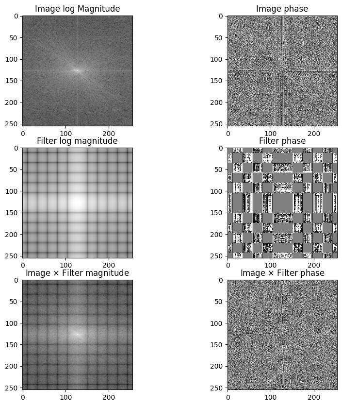

```python
filter_ft, im2_ft, im2 = filterFrequency(im, avgFilter, 11)
im2_space = averageFilterSpace(im, 2)
magnitude_or = np.log(np.absolute(im2_ft))
phase_or = np.angle(im2_ft)
magnitude_filter = np.log(np.absolute(filter_ft))
phase_filter = np.angle(filter_ft)
magnitude_prod = np.log(np.absolute(filter_ft*im2_ft))
phase_prod = np.angle(filter_ft*im2_ft)
vpu.showInGrid([magnitude_or, phase_or, magnitude_filter, phase_filter, magnitude_prod, phase_prod], figure_size=(10,10), m=3,n=2, subtitles=["Image log Magnitude", "Image phase", "Filter log magnitude", "Filter phase",
                                                                                                                             "Image $\\times$ Filter magnitude", "Image $\\times$ Filter phase"])
```

```
8 4 2
```

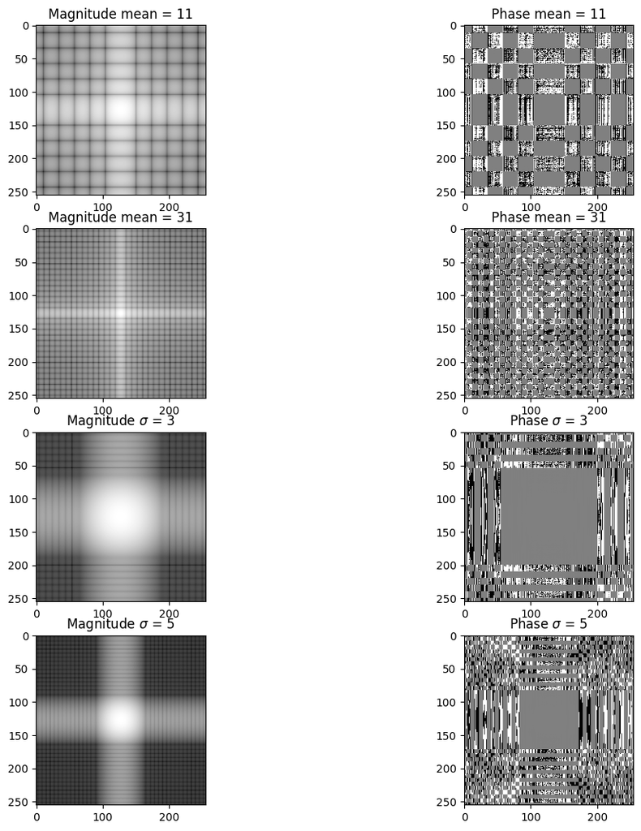

```python
filter_ft, _, im2 = filterFrequency(im, avgFilter, 11)
filter_ft2, _, im3 = filterFrequency(im, avgFilter, 31)
filter_ft3, _, im4 = filterFrequency(im, gaussianFilter, 3)
filter_ft4, _, im5 = filterFrequency(im, gaussianFilter, 5)

magnitude_filter = np.log(np.absolute(filter_ft))
phase_filter = np.angle(filter_ft)
magnitude_filter2 = np.log(np.absolute(filter_ft2))
phase_filter2 = np.angle(filter_ft2)
magnitude_filter3 = np.log(np.absolute(filter_ft3))
phase_filter3 = np.angle(filter_ft3)
magnitude_filter4 = np.log(np.absolute(filter_ft4))
phase_filter4 = np.angle(filter_ft4)
vpu.showInGrid(
    [
        magnitude_filter,
        phase_filter,
        magnitude_filter2,
        phase_filter2,
        magnitude_filter3,
        phase_filter3,
        magnitude_filter4,
        phase_filter4,
    ],
    figure_size = (13, 13),
    m=4,
    n=2,
    subtitles=[
        "Magnitude mean = 11",
        "Phase mean = 11",
        "Magnitude mean = 31",
        "Phase mean = 31",
        "Magnitude $\\sigma$ = 3",
        "Phase $\\sigma$ = 3",
        "Magnitude $\\sigma$ = 5",
        "Phase $\\sigma$ = 5",
    ],
)
```

# Exercise 3

I plotted both the time vs the mask size and the time vs the image size. In both you can see the influence of the image size and the mask size on the time it takes to compute the filtered image in the spatial and frequency domains. It is obvious that the frequency domain is faster and almost constant compared to the spatial domain.

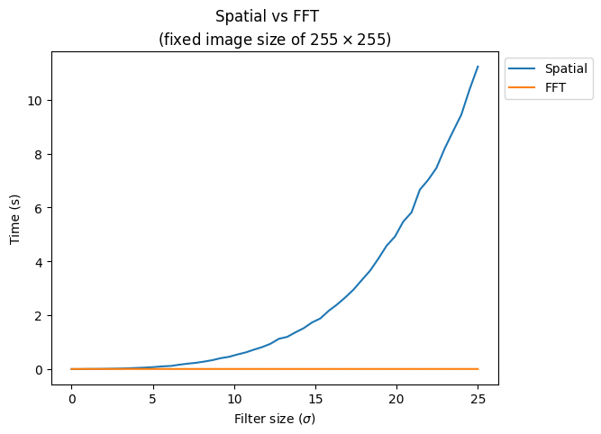

```python
file = './imgs-P3/lena255.pgm'
im = np.array(Image.open(file).convert('L'))
filterSizes = np.linspace(0,25,50)
imageSizes = [64, 96, 128, 160, 192, 224, 255]
time_normal = []
time_ft = []
for f in filterSizes:
    start = timer()
    im2 = filterFrequency(im, gaussianFilter, f)
    end = timer()
    time_ft.append(end - start)
    start = timer()
    im3 = gaussianFilterSpace(im, f)
    end = timer()
    time_normal.append(end - start)
plt.plot(filterSizes, time_normal, label="Spatial")
plt.plot(filterSizes, time_ft, label="FFT")
plt.suptitle("Spatial vs FFT")
plt.title("(fixed image size of $255\\times255$)")
plt.xlabel("Filter size ($\\sigma$)")
plt.ylabel("Time (s)")
plt.legend(bbox_to_anchor=(1, 1))
plt.show()
```

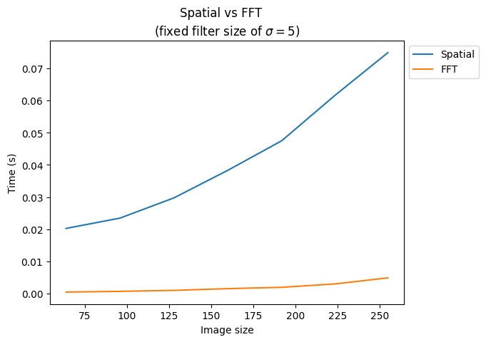

```python
file = './imgs-P3/lena255.pgm'
im = np.array(Image.open(file).convert('L'))
filterSizes = [0.5, 1, 1.5, 2.0, 2.5, 3, 3.5, 4.0, 4.5, 5.0, 5.5, 6.0]
imageSizes = [64, 96, 128, 160, 192, 224, 255]
time_normal = []
time_ft = []
for i in imageSizes:
    start = timer()
    im2 = filterFrequency(im[:i,:i], gaussianFilter, 5)
    end = timer()
    time_ft.append(end - start)
    start = timer()
    im3 = gaussianFilterSpace(im[:i,:i], 5)
    end = timer()
    time_normal.append(end - start)
plt.plot(imageSizes, time_normal, label="Spatial")
plt.plot(imageSizes, time_ft, label="FFT")
plt.suptitle("Spatial vs FFT")
plt.title("(fixed filter size of $\\sigma = 5$)")
plt.xlabel("Image size")
plt.ylabel("Time (s)")
plt.legend(bbox_to_anchor=(1, 1))
plt.show()
```